# Vietnam Draft, Part 2

SOLUTIONS

Updated: Saturday, December 01, 2018 @ 03:06:46 PM

```r
library(tidyverse)
draft <- read.csv("https://raw.githubusercontent.com/STAT-JET-ASU/Datasets/master/Instructor/vietnamdraft.csv")
```

For all tests, write the null and alternative hypotheses, report the test statistic and the p-value, state whether or not you reject the null hypothesis, and then give your conclusion in terms of the original question.

1. Perform both a traditional and a permutation hypothesis to determine whether the mean draft number for the second half of the year and the mean draft number for the first half of the year are significantly different. If so, which mean is smaller?

Ho: $\mu_{first} = \mu_{second}$

Ha: $\mu_{first} \neq \mu_{second}$

Traditional Test:

```r
t.test(draft$num1970 ~ draft$halfyear)
```

```
    Welch Two Sample t-test

data:  draft$num1970 by draft$halfyear
t = 4.1959, df = 362.56, p-value = 3.422e-05
alternative hypothesis: true difference in means is not equal to 0
95 percent confidence interval:
 24.12198 66.67854
sample estimates:
 mean in group First mean in group Second
            206.3242             160.9239
```

Permutation Test:

```r
halfmeans <- draft %>% group_by(halfyear) %>%  summarize(xbar = mean(num1970))
print(halfmeans)
```

```
# A tibble: 2 x 2
  halfyear  xbar
  <fct>    <dbl>
1 First     206.
2 Second    161.
```

```r
teststat <- -diff(halfmeans$xbar)

N <- 10^5 - 1
permMeanDiff <- numeric(N)

testdata <- draft$num1970

for (i in 1:N){
   index  <- sample(366, 182)
   first  <- testdata[index]
   second <- testdata[-index]
   permMeanDiff[i] <- mean(first) - mean(second)
}

pvalue.lower <- (sum(permMeanDiff <= teststat) + 1) / (N + 1)
pvalue.upper <- (sum(permMeanDiff >= teststat) + 1) / (N + 1)
pvalue.twotail <- 2 * min(pvalue.lower, pvalue.upper)

print(teststat)
```

```
[1] 45.40026
```

```r
print(pvalue.twotail)
```

```
[1] 4e-05
```

Conclusions: We reject Ho at the α = 0.05 level and conclude that two means are different. Based on the sample means, the second half of the year had lower draft numbers, on average, than the first half of the year.

Ho: $\pi_{first} = \pi_{second}$

Ha: $\pi_{first} < \pi_{second}$

Traditional Test:

```r
draft <- draft %>% mutate(leq195 = ifelse(num1970 <= 195, "drafted", "not drafted"))

prop.test(table(draft$halfyear, draft$leq195), alternative = "less", correct = FALSE)
```

```
    2-sample test for equality of proportions without continuity
    correction

data:  table(draft$halfyear, draft$leq195)
X-squared = 17.505, df = 1, p-value = 1.433e-05
alternative hypothesis: less
95 percent confidence interval:
 -1.0000000 -0.1344966
sample estimates:
   prop 1    prop 2
0.4230769 0.6413043
```

Permutation Test:

```r
halfprops <- draft %>% group_by(halfyear) %>%  summarize(phat = mean(leq195 == "drafted"))
print(halfprops)
```

```
# A tibble: 2 x 2
  halfyear  phat
  <fct>    <dbl>
1 First    0.423
2 Second   0.641
```

```r
teststat <- -diff(halfprops$phat)

N <- 10^5 - 1
permPropDiff <- numeric(N)

testdata <- draft$leq195

for (i in 1:N){
   index  <- sample(366, 182)
   first  <- testdata[index]
   second <- testdata[-index]
   permMeanDiff[i] <- mean(first == "drafted") - mean(second == "drafted")
}

pvalue.lower <- (sum(permPropDiff <= teststat) + 1) / (N + 1)

print(teststat)
```

```
[1] -0.2182274
```

```r
print(pvalue.lower)
```

```
[1] 1e-05
```

Conclusions: We reject Ho at the α = 0.05 level and conclude that the first half of the year had a lower proportion of draft numbers that were less than or equal to 195 than the second half of the year.

3. The overall distribution of draft numbers is discrete uniform. If the process was truly random, then the distribution of draft numbers in each half of the year should also be essentially uniform as well. Perform a goodness of fit test to determine whether draft numbers in the second half of the year are uniformly distributed.

Ho: The draft numbers in the second half of the year are uniformly distributed.

Ha: The draft numbers in the second half of the year are not uniformly distributed.

Traditional Test:

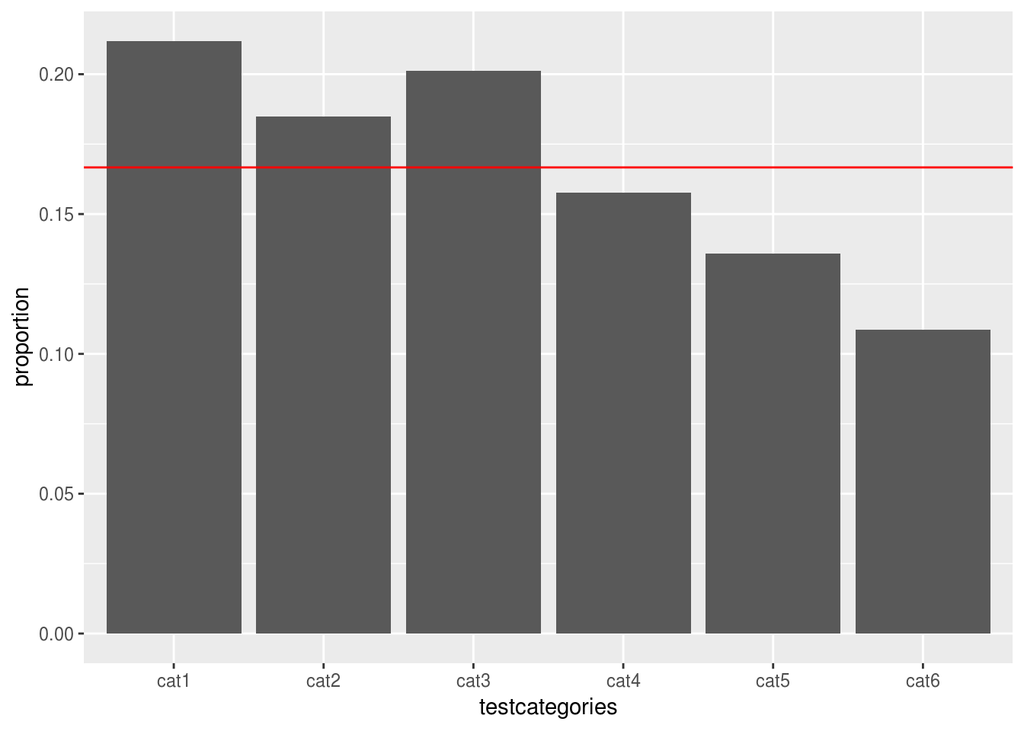

```r
draft <- draft %>% filter(halfyear == "Second") %>%
  mutate(testcategories = case_when(num1970 >= 1   & num1970 <= 61  ~ 'cat1',
                                    num1970 >= 62  & num1970 <= 122 ~ 'cat2',
                                    num1970 >= 123 & num1970 <= 183 ~ 'cat3',
                                    num1970 >= 184 & num1970 <= 244 ~ 'cat4',
                                    num1970 >= 245 & num1970 <= 305 ~ 'cat5',
                                    num1970 >= 306 & num1970 <= 366 ~ 'cat6'))

observed <- table(draft$testcategories)

ggplot(draft, aes(x = testcategories)) +
  geom_bar(aes(y=..count../sum(..count..))) +
  geom_hline(yintercept = 1/6, col = "red") +
  ylab("proportion")
```

```r
chisq.test(observed)
```

```
    Chi-squared test for given probabilities

data:  observed
X-squared = 8.7826, df = 5, p-value = 0.1181
```

Conclusions: We fail to reject Ho at the α = 0.05 level and conclude that draft numbers in the second half of the year are uniformly distributed. However, the barplot looks a little nonrandom.

4. How do your analyses support the assertion that the draft was unfair? Why are they not *proof* of unfairness?

END PART 2